# The Ramen Rater

곽영효

2022-08-08

## 출처: Top Ramen Ratings 2022

https://www.kaggle.com/datasets/ankanhore545/top-ramen-ratings-2022 https://www.theramenrater.com/

## 서론

[figure not shown]

ramenrater

2002년부터 라면 외길을 걸어온 라면 전문 리뷰어 ‘The Ramen Rater’

그가 블로그에서 20년이란 세월동안 전 세계의 라면들에 매겨온 평점에 대한 데이터다.

## 라?면

[figure not shown]

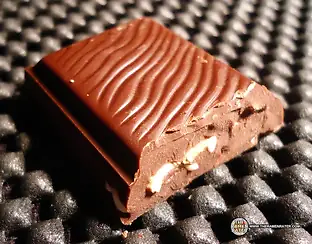

[figure not shown]

bar와 can타입의 항목이 있었는데 라면이라고 부르기는 어려운 음식들이었다.

이들을 제외하고 분석을 실시했다.

```r
summary(df)
```

```
##     Review..       Brand             Variety             Style
##  Min.   :   1   Length:4120        Length:4120        Length:4120
##  1st Qu.:1031   Class :character   Class :character   Class :character
##  Median :2060   Mode  :character   Mode  :character   Mode  :character
##  Mean   :2060
##  3rd Qu.:3090
##  Max.   :4120
##    Country             Stars
##  Length:4120        Length:4120
##  Class :character   Class :character
##  Mode  :character   Mode  :character
##
##
##
```

## 항목 수 상위 10개국

## 상위 10개국의 라면 개수

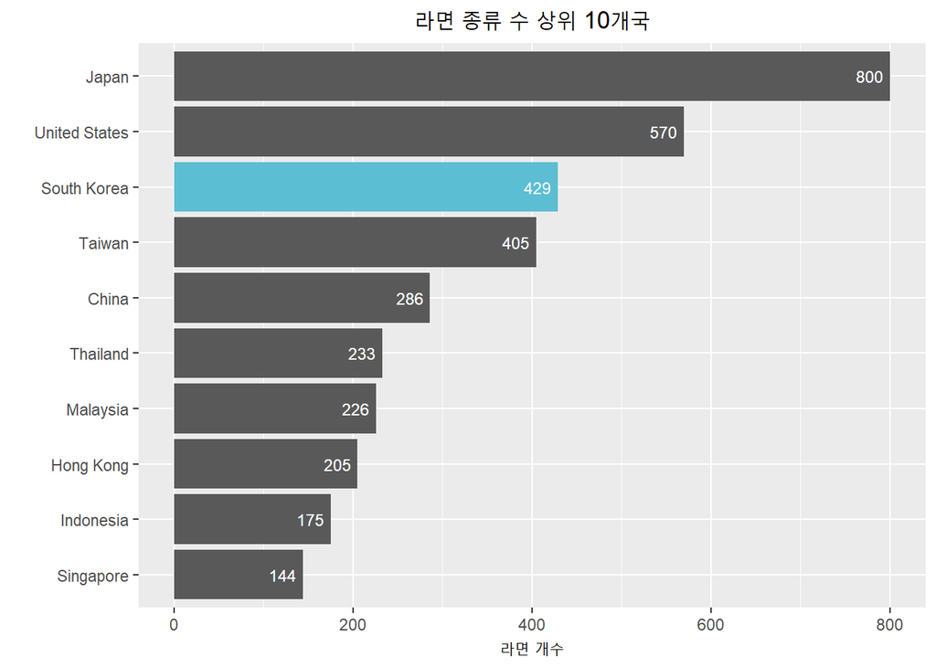

```r
graph1
```

## 국가별 라면 평균 평점

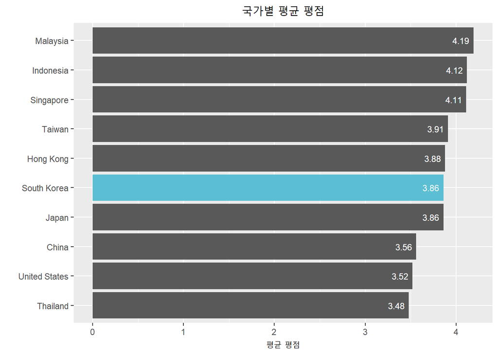

```r
graph5
```

## 분석

태국을 제외한 말레이시아, 인도네시아, 싱가포르 라면들의 평균 평점이 1위 그룹을 형성했다.

한국, 일본, 미국처럼 개수가 많았던 국가들은 저조한 평균 평점을 기록했다. 생산한 라면 종류가 많은만큼, 애매한 상품들도 많이 개발되었기 때문.

## 4점 이상의 별점을 받은 라면의 비율

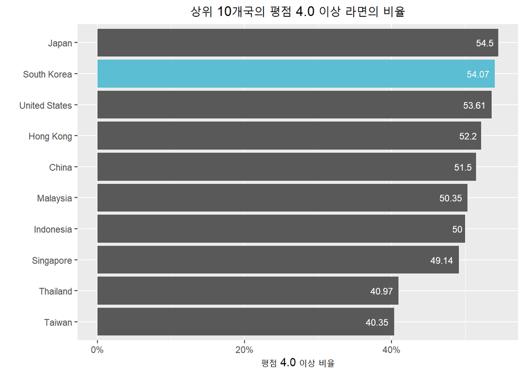

```r
graph2
```

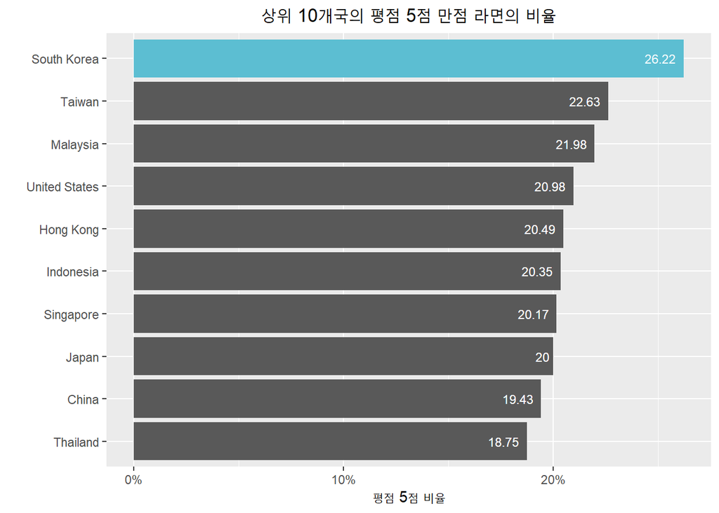

```r
graph7
```

## 분석

5점 만점을 받은 비율은 한국이 압도적으로 1위. - 신라면 시리즈나 불닭 시리즈처럼 파생상품 개발에 적극적인 것이 이유로 판단됨.

4점 이상 비율에선 10개국 중 꼴지였던 대만이 5점 만점 비율에선 2위를 차지.

이와 반대로 4점 이상 비율이 1위였던 일본은 5점 만점 비율에선 8위라는 낮은 순위.

## 라면 포장 방법에 따른 종류 개수

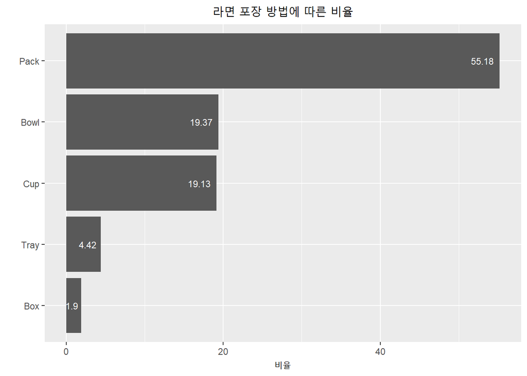

```r
graph3
```

## 분석

한국에선 왕뚜껑, 공화춘과 같은 Bowl형 컵라면을 Cup형 컵라면에 비해서 보기 힘듦.

하지만, 의외로 전세계적으로는 Bowl형과 Cup형의 가짓수가 비슷

## 라면 포장 방법에 따른 평균 별점

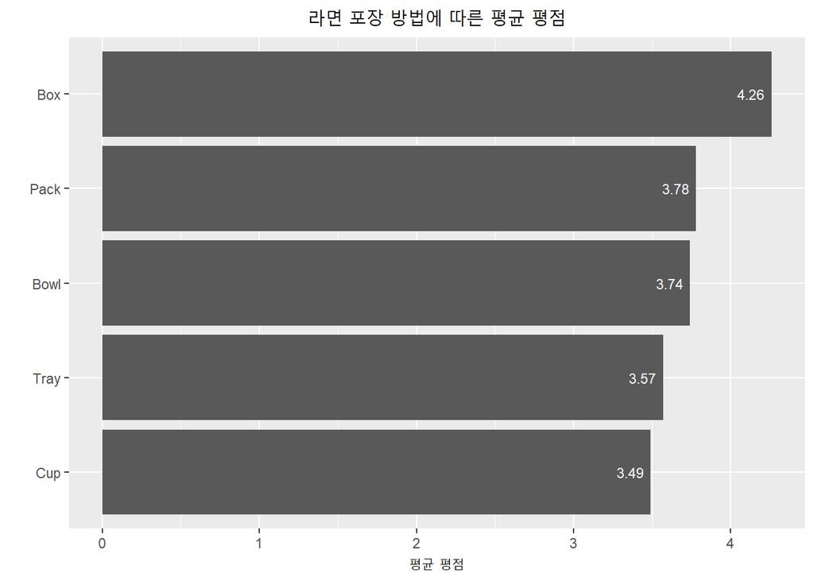

```r
graph4
```

## 분석

[figure not shown]

ramen_box

위와 같은 박스형 라면들이 평균 별점이 제일 높았다.

박스형으로 포장된 것들은 보통 고가형 라인업이 많기 때문인 것으로 생각된다.

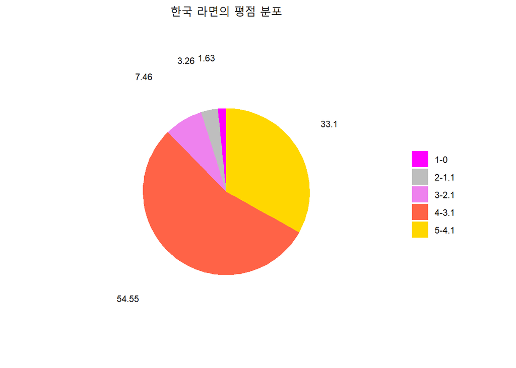

```r
graph6
```

## 번외: The Ramen Rater가 뽑은 한국의 역체라면 2021 Edition

[figure not shown]

rank10_신라면블랙

[figure not shown]

rank09_삼양치즈라면

[figure not shown]

rank08_팔도치즈라면

[figure not shown]

rank07_신라면건면

[figure not shown]

rank06_라이트_불닭볶음면

[figure not shown]

rank05_짜장불닭라볶이

[figure not shown]

rank04_팔도라볶이

[figure not shown]

rank03_삼양라면_매운맛

[figure not shown]

rank02_진짬뽕

[figure not shown]

rank01_까르보불닭라볶이

## 번외2: 별점 5점 만점을 획득한 한국 라면 리스트

```r
df[df$Country == 'South Korea' & df$Stars == 5.00,]$Variety
```

```
##  [1] "Cheese Rapokki"
##  [2] "Cheese Ramyun"
##  [3] "Mac & Cheese Spaghetti"
##  [4] "Shin Light Air Dried Noodle Soup"
##  [5] "Mr Kimchi Stirfried Kimchi Ramen"
##  [6] "Bul Jjamppong"
##  [7] "Buldak Light"
##  [8] "Big Gomtang Instant Noodle Soup Mix"
##  [9] "King Lid Ramen Noodle Soup"
## [10] "Big 3 Instant Ramen Bowl"
## [11] "Mr. Kimchi Stirfried Kimchi Ramen"
## [12] "Jjajang Buldak Ramen Topokki"
## [13] "Carbo HOT Chicken Flavor Topokki"
## [14] "Jjajang Ttoekbokki With Noodles"
## [15] "Pho Rice Noodle HOT"
```

[output cut: 60 more lines]